# FigureYa206scHeatmap

**Author(s)**: Zongcheng Li; Yasi Zhang  
**Reviewer(s)**: Ying Ge  
**Date**: 2025-05-20

# Academic Citation

If you use this code in your work or research, we kindly request that you cite our publication:

Xiaofan Lu, et al. (2025). FigureYa: A Standardized Visualization Framework for Enhancing Biomedical Data Interpretation and Research Efficiency. iMetaMed. https://doi.org/10.1002/imm3.70005

# 需求描述

# Demand description

这个图信息量很大，非常高大上，热图和气泡图合用，展示差异富集信号通路信息。

This diagram is packed with information and looks very high-end. The combination of a heatmap and bubble chart effectively displays differential enrichment signaling pathways.

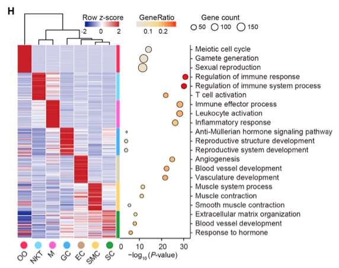

出自：https://linkinghub.elsevier.com/retrieve/pii/S0092867420300568

图1. 猕猴卵巢单细胞RNA测序分析揭示具有独特转录特征的卵巢细胞亚群。 (H) 左图：热图展示各细胞类型中前50个特异性表达基因的表达特征，每个基因的值为行标准化Z分数；右图：代表性GO条目。

Source: https://linkinghub.elsevier.com/retrieve/pii/S0092867420300568

Figure 1. Distinct Ovarian Cell Subpopulations with Transcriptional Signatures Determined by Single-Cell RNA-Seq Analysis of Monkey Ovaries. (H) Left: heatmap showing expression signatures of top 50 specifically expressed genes in each cell type; the value for each gene is row-scaled Z score. Right: representative GO terms.

# 应用场景

# Application scenarios

单细胞RNA-seq的表达谱和基因功能富集分析结果的展示。

左侧表达谱热图跟右侧富集分析结果对应，更直观。

Single-cell RNA-seq expression profiles and gene functional enrichment analysis results.

The expression heatmap on the left corresponds to the enrichment analysis results on the right, providing a more intuitive visualization.

# 环境设置

# Environment Setup

```r
source("install_dependencies.R")
```

```
## Starting R package installation...
## ===========================================
##
## Installing CRAN packages...
## Package already installed: Hmisc
## Package already installed: RColorBrewer
## Package already installed: Seurat
## Package already installed: aplot
## Package already installed: batchelor
## Package already installed: magrittr
## Package already installed: patchwork
## Package already installed: pheatmap
## Package already installed: tidyverse
##
## ===========================================
## Package installation completed!
## You can now run your R scripts in this directory.
```

```r
library(tidyverse)
library(magrittr)
library(Seurat) # v3.1.5
```

```r
library(pheatmap)
library(RColorBrewer)
library(aplot)
library(patchwork)

# 显示英文报错信息
# Show English error messages
Sys.setenv(LANGUAGE = "en")

# 禁止chr转成factor
# Prevent character-to-factor conversion
options(stringsAsFactors = FALSE)
```

# 输入文件

# Input Files

## 下载单细胞RNA-seq数据

## Download Single-Cell RNA-Seq Data

1. UMI count，从NCBIGSE130664下载：`GSE130664_merge_UMI_count.txt.gz`文件。
2. UMI counts: Download the `GSE130664_merge_UMI_count.txt.gz` file from NCBIGSE130664

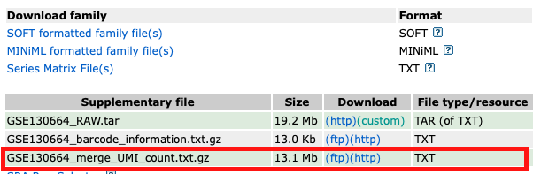

2. metadata: 从[例文的](https://doi.org/10.1016/j.cell.2020.01.009)Supplementary Tables获得：`1-s2.0-S0092867420300568-mmc1.xlsx`
3. metadata: Obtain from the supplementary tables of the [example paper](https://doi.org/10.1016/j.cell.2020.01.009): `1-s2.0-S0092867420300568-mmc1.xlsx`

## 读取数据

## Read data

```r
# 读取UMI计数矩阵
# Read UMI count matrix
umi <- read.table(file = gzfile("GSE130664_merge_UMI_count.txt.gz"), header = T, row.names = 1, sep = "\t")

# 读取质控指标（Excel第二工作表）
# Read QC metrics (Excel sheet 2)
qc <- readxl::read_excel("1-s2.0-S0092867420300568-mmc1.xlsx", sheet = 2)

# 读取元数据（Excel第三工作表）并设置细胞ID为行名
# Read metadata (Excel sheet 3) with cell IDs as rownames
meta <- readxl::read_excel("1-s2.0-S0092867420300568-mmc1.xlsx", 3) %>%
  column_to_rownames("cell")
```

# 数据预处理

# Data Preprocessing

看方法学部分： QUANTIFICATION AND STATISTICAL ANALYSIS -> Single-Cell RNA-Seq Data Processing

See Methods:  
QUANTIFICATION AND STATISTICAL ANALYSIS -> Single-Cell RNA-Seq Data Processing

```r
# 细胞质量控制
# Cell Quality Control
cells <- qc %>%
  filter(`Mapping rate` >= 0.2 &
           `Gene number` >= 700 &
           UMI >= 3000) %>%
  pull(Rename)

# 创建Seurat对象
# Create Seurat Object
sc <- CreateSeuratObject(counts = umi[,cells], meta.data = meta)
# 表达量转换
# Expression Transformation
counts_matrix <- LayerData(sc, layer = "counts")
normalized_data <- apply(counts_matrix, 2, function(x){
  log2(10^5 * x / sum(x) + 1)
})
sc <- SetAssayData(sc, layer = "data", new.data = normalized_data)

# 细胞过滤
# Cell Filtering
sc <- sc[,sc$cluster != "other"]

# 细胞群重命名
# Cluster Renaming
sc$cluster_short <- factor(
  plyr::mapvalues(sc$cluster,
                  c("Oocyte", "Natural killer T cell", "Macrophage",
                    "Granulosa cell", "Endothelial cell",
                    "Smooth muscle cell", "Stromal cell"),
                  c("OO", "NKT", "M", "GC", "EC", "SMC", "SC")),
  levels = c("OO", "NKT", "M", "GC", "EC", "SMC", "SC"))

# 配色方案
# Color Scheme
cluster_colors <- setNames(brewer.pal(7, "Set1"), levels(sc$cluster_short))

# 数据保存
# Data Saving
#save(sc, cluster_colors, file = "sc.seurat.Rdata")

# 表达矩阵导出
# Expression Matrix Export
#write.csv(sc@assays$RNA@data, "easy_input_expr.csv", quote = F)
```

# 差异表达分析

# Differential Expression Analysis

看方法学部分:  
QUANTIFICATION AND STATISTICAL ANALYSIS -> Identification of Cell Types and Cell Type-Specific Markers

原文：我们使用标准曲线下面积（AUC）分类器，通过R包Seurat（Satija等，2015）中的FindAllMarkers函数鉴定细胞类型特异性标记（不同细胞类型间的差异表达基因）。只有当**log2转换后的TPM平均差异大于0.5、对应功效值大于0.25且表达细胞比例（TPM ≥ 0）大于30%时**，才被选为**标记基因**。

See Methods:  
QUANTIFICATION AND STATISTICAL ANALYSIS -> Identification of Cell Types and Cell Type-Specific Markers

Original text: We used a standard area under the curve (AUC) classifier to identify cell type-specific markers (DEGs among different cell types) with the function FindAllMarkers in the R package Seurat (Satija et al., 2015). **Markers** were selected only if the average difference of the **log2-transformed TPM was greater than 0.5, with a corresponding power value greater than 0.25 and a percentage of expressed cells (TPM s 0) greater than 30%.**

```r
#load(file = "sc.seurat.Rdata")

# 设置细胞标识
# Set Cell Identity
Idents(sc) <- "cluster_short"

# 差异表达分析
# Differential Expression Analysis
degs <- FindAllMarkers(sc, logfc.threshold = 0.5,
                       test.use = "roc",
                       return.thresh = 0.25,
                       min.pct = 0.3, only.pos = T)
# 注意：实际过滤时似乎只有logfc.threshold参数有效
# NOTE: seem like only parameter logfc.threshold is valid when do filter

# 筛选显著差异基因
# Filter Significant DEGs
degs_sig <- degs %>%
  filter(pct.1 > 0.3 &
           power > 0.25) %>%
  filter(cluster != "other") %>%
  arrange(cluster, -power)

# 结果输出
# Results Export
write.csv(degs_sig, file = "output_degs_sig.csv")

# 分群组输出基因列表
# Export Gene Lists by Cluster
for (clustername in levels(sc$cluster_short)){
  write.table(rownames(degs_sig[degs_sig$cluster == clustername, ]), paste0("output_deg_", clustername, ".txt"), row.names = F, col.names = "Gene", quote = F)
}
```

# 富集分析

# Enrichment analysis

为重复原文，这里也用[ToppGene做富集分析](https://toppgene.cchmc.org/enrichment.jsp)（一个简单易用的在线工具）。

原文：GO analysis of cell type-specific markers was performed with ToppGene (Chen et al., 2009). We selected GO terms representing the function of each cell type with **P value < 0.05 among top 30 terms** (Figure 1H).

1. 用除了Excel以外的文本编辑器，每次打开一个`output_deg_*.txt`文件，复制其中的基因名，粘贴到`Enrichment Gene Set`框，`Background Gene Set`框可以留空。

To replicate the original paper, we also used [ToppGene for enrichment analysis](https://toppgene.cchmc.org/enrichment.jsp) (an easy-to-use webserver).

Original text: GO analysis of cell type-specific markers was performed with ToppGene (Chen et al., 2009). We selected GO terms representing the function of each cell type with **P value < 0.05 among top 30 terms** (Figure 1H).

1. Use a text editor other than Excel to open each `output_deg_*.txt` file, copy the gene names, and paste them into the `Enrichment Gene Set` box. The `Background Gene Set` box can be left empty.

[figure not shown]

2. 例文选了GO的MF、BP和CC，你也可以尝试其他注释
3. The example paper selected GO terms for MF, BP, and CC. You may also try other annotations.

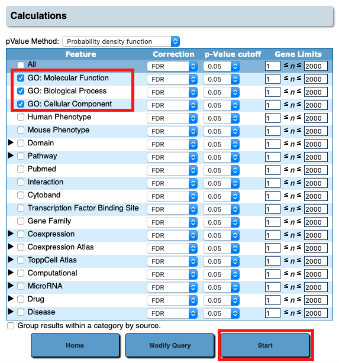

4. 点击Download下载，把下载到的文件命名为`ouput_enrich_[cluster的名字].txt`，用于画dotplot。

例如：打开`output_deg_OO.txt`，复制基因名，用ToppGene富集分析获得的文件重命名为`output_enrich_OO.txt`。

3. Click Download to save the file, and rename it as `ouput_enrich_[cluster name].txt` for dotplot visualization.

For example: Open `output_deg_OO.txt`, copy the gene names, use ToppGene for enrichment analysis, and rename the obtained file as `output_enrich_OO.txt`.

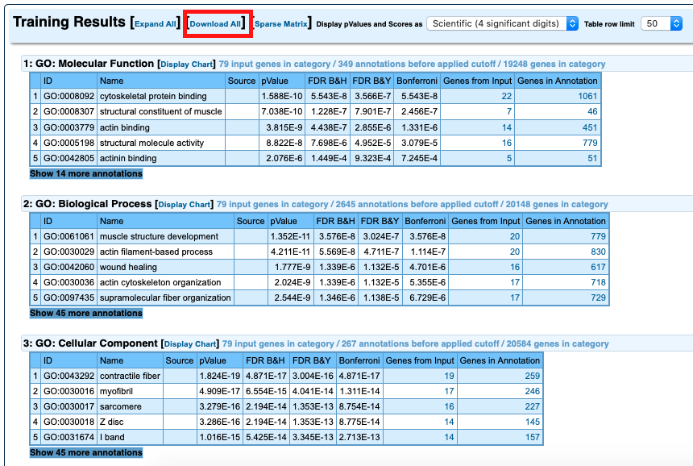

> 所有cluster都按上述方法操作和命名，并保存在当前文件夹下。后面画图时会根据文件名批量读入富集分析结果文件。

> 另外，还可以用clusterprofiler等命令行式的工具，就可以批量做，更方便。后面画图用到的这几列在所有富集分析结果中都有：Name（term）, p-value, Hit Count in Query List, Hit Count in Genome（背景）

> Process and name all clusters according to the above method, and save them in the current folder. The enrichment analysis result files will be batch imported based on filenames during subsequent plotting.

> Alternatively, command-line tools like clusterProfiler can be used for batch processing, which is more convenient. The following columns required for subsequent plotting are present in all enrichment analysis results: Name (term), p-value, Hit Count in Query List, Hit Count in Genome (background).

# 开始画图

# Plotting

分别画热图和点图，然后拼起来。输出的pdf文件是矢量图，可以用Adobe Illustrator等矢量图编辑器进一步修饰图和文字。

Generate heatmaps and dot plots separately, then combine them. The output PDF files are vector graphics that can be further edited (e.g., adjusting figures and text) using vector graphic editors like Adobe Illustrator.

## 热图

## Heatmap

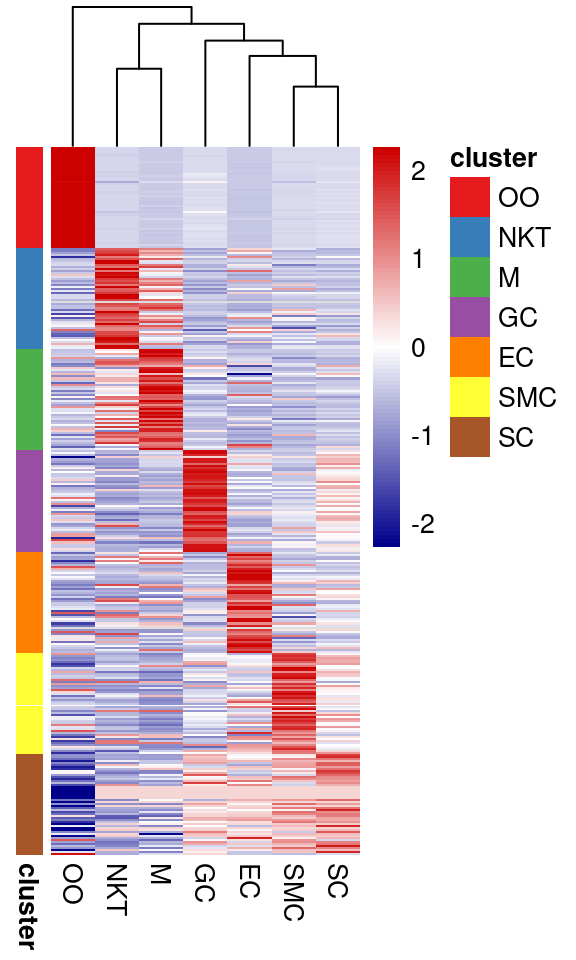

```r
# 加载前面预处理好的scRNA-Seq数据，要用到表达矩阵、cluster及配色
#(load(file = "sc.seurat.Rdata"))

# 筛选热图用差异基因
# Select DEGs for Heatmap
degs_top50 <- degs_sig %>%
#  filter(cluster!="other") %>%
  group_by(cluster) %>%
  top_n(50, power) %>%
  top_n(50, avg_diff) %>%
  arrange(cluster, -power)

# 获取标准化表达数据
# Get Normalized Expression Data
norm_data <- GetAssayData(sc, layer = "data")

# 基因存在性检查
# Gene Presence Check
missing_genes <- setdiff(degs_top50$gene, rownames(norm_data))
if (length(missing_genes) > 0) {
  warning("The following genes are not present in the expression matrix and have been automatically excluded: ", paste(missing_genes, collapse = ", "))
  degs_top50 <- degs_top50[degs_top50$gene %in% rownames(norm_data), ]
}

# 计算cluster平均表达量
# Calculate Cluster-wise Mean Expression
avgData <- norm_data[degs_top50$gene, ] %>%
  apply(1, function(x) {
    tapply(x, sc$cluster_short, mean)
  }) %>%
  t()

# 数据标准化处理
# Data Normalization
phData <- MinMax(scale(avgData), -2, 2)
rownames(phData) <- 1:nrow(phData)

# 绘制热图
# Generate Heatmap
phres <- pheatmap(
  phData,
  color = colorRampPalette(c("darkblue", "white", "red3"))(99),
  scale = "row",
  cluster_rows = F,
  cluster_cols = T,
  clustering_method = "complete",
  show_rownames = F,
  annotation_row = data.frame(cluster = degs_top50$cluster),
  annotation_colors = list(cluster = cluster_colors))
```

## 点图

## Dotplot

原文：We selected GO terms representing the **function of each cell type** with P value < 0.05 among top 30 terms (Figure 1H).

原图每个cluster各画了三个GO term。实际使用时，结合背景知识，把想展示的term写在`go_used`里。

Original text: We selected GO terms representing the **function of each cell type** with P value < 0.05 among top 30 terms (Figure 1H).

The original figure displayed three GO terms for each cluster. For practical application, incorporate domain knowledge and specify the terms you wish to present in the `go_used` list.

```r
# 定义要展示的GO terms
# Define GO terms to display
go_used <- list(
  OO = c("meiotic cell cycle", "gamete generation", "sexual reproduction"),
  NKT = c("regulation of immune response", "regulation of immune system process", "T cell activation"),
  M = c("immune effector process", "leukocyte activation", "inflammatory response"),
  GC = c("anti-Mullerian hormone signaling pathway", "reproductive structure development", "reproductive system development"),
  EC = c("angiogenesis", "blood vessel development", "vasculature development"),
  SMC = c("muscle system process", "muscle contraction", "smooth muscle contraction"),
  SC = c("extracellular matrix organization", "blood vessel development", "response to hormone")
)

# 统计各cluster差异基因数量
# Count DEGs per cluster
degs_n <- table(degs_sig$cluster)

# 批量读取富集结果
# Batch load enrichment results
lapply(levels(sc$cluster_short), function(i){

  # 这里用文章附件里的富集分析结果画图
  # Using supplementary data from paper
  tmp <- readxl::read_excel("1-s2.0-S0092867420300568-mmc1.xlsx", paste0("GO_", i))

  # 实际分析时使用以下代码读取本地结果
  # For actual analysis use this to load local results:
  #tmp <- read.table(paste0("output_enrich_", i, ".txt"), sep = "\t", header = T, check.names = F)

  # 提取指定GO term的结果
  # Extract results for specified GO terms
  cbind(tmp[match(go_used[[i]], tmp$Name),
            c("Name", "p-value", "Hit Count in Query List", "Hit Count in Genome")],
        cluster = i, n_deg = degs_n[[i]])
}) %>% do.call(rbind, .) -> dotData

# 预览数据
# Preview data
head(dotData)
```

```
##                                  Name   p-value Hit Count in Query List
## 1                  meiotic cell cycle 1.748e-14                      74
## 2                   gamete generation 3.358e-12                     150
## 3                 sexual reproduction 1.072e-11                     175
## 4       regulation of immune response 3.910e-31                      50
## 5 regulation of immune system process 5.583e-31                      61
## 6                   T cell activation 2.416e-22                      33
##   Hit Count in Genome cluster n_deg
## 1                 237      OO  4261
## 2                 692      OO  4261
## 3                 857      OO  4261
## 4                 899     NKT   212
## 5                1506     NKT   212
## 6                 506     NKT   212
```

```r
# 计算x轴范围
# Calculate x-axis limit
(xmax <- round(max(-log10(dotData$`p-value`))))
```

```
## [1] 30
```

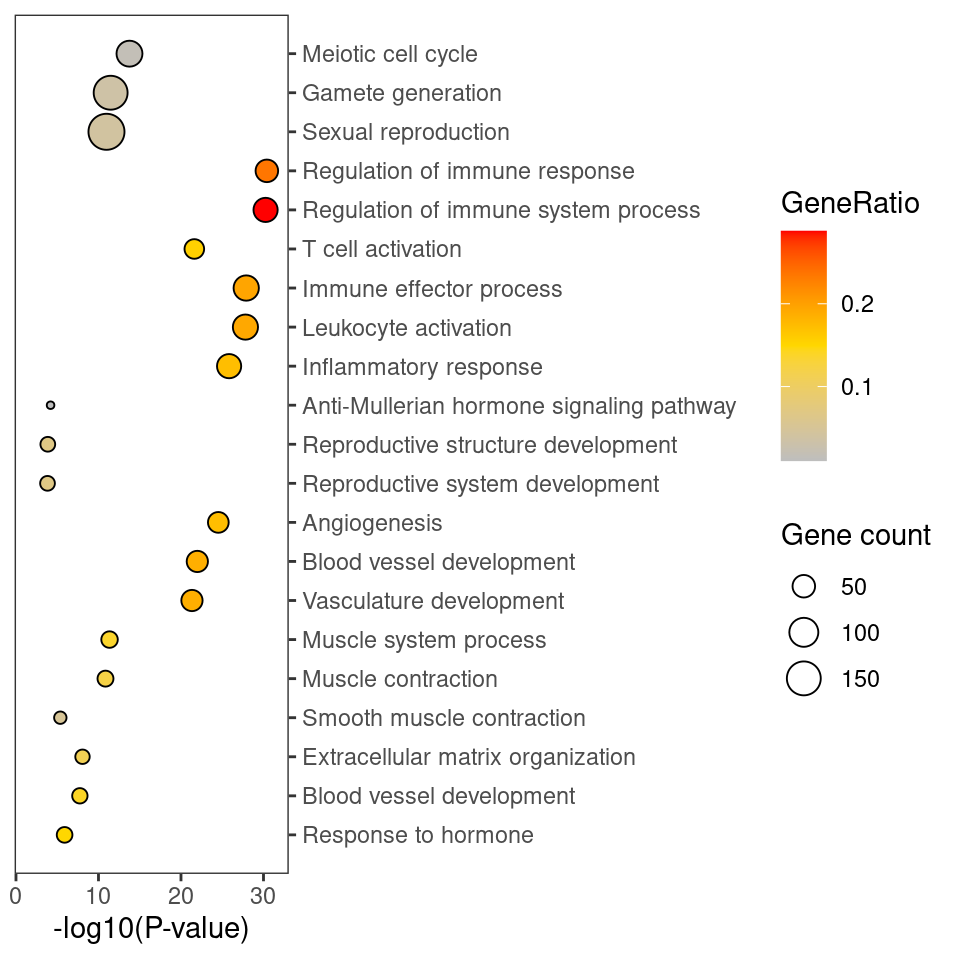

```r
# 绘制点图
# Create dot plot
dotplot <- ggplot(cbind(dotData, Order = nrow(dotData):1)) +
  geom_point(mapping = aes(x = -log10(`p-value`),
                           y = Order,
                           size = `Hit Count in Query List`,
                           fill = `Hit Count in Query List`/n_deg),
             shape = 21) +
  scale_fill_gradientn(colours = c("grey", "gold", "red")) +
  scale_y_continuous(position = "right",
                     breaks = 1:nrow(dotData),
                     labels = Hmisc::capitalize(rev(dotData$Name))) +
  scale_x_continuous(breaks = seq(0, xmax, 10),
                   expand = expansion(mult = c(.15, .1))) +

  labs(x = "-log10(P-value)", y = NULL) +
  guides(size = guide_legend(title = "Gene count"),
         fill = guide_colorbar(title = "GeneRatio")) +
  #theme_classic() +
  theme_bw() +
  theme(panel.grid =element_blank())

dotplot
```

## 合并

## Combined

你可以使用Adobe Illustrator对以下图表进行修饰完善

You can go to Adobe Illustrator to polish the following figures

```r
# 提取热图图形对象
# Extract heatmap graphical object
gh <- phres$gtable

# 转换ggplot点图为图形对象
# Convert ggplot dotplot to graphical object
gd <- ggplotGrob(dotplot)

# 组合图形
# Combine plots
combined_plot <- wrap_elements(gh) + wrap_elements(gd) +
  plot_layout(widths = c(1.2, 1.6))

# 保存组合图
# Save combined plot
ggsave("scHeatmap.pdf", combined_plot, width = 12, height = 8)
```